# Microglia_monocyte_comparisons

Gijsje

2/24/2021

# Load MiGASTi

#metadata + genes_counts

```r
metadata <- read.table("~/Documents/MiGASti/Databases/metadata.txt")
#set rownames to Sample
row.names(metadata) <- metadata$Sample
setwd("~/Documents/MiGASti/Databases")
#exclude samples that did not pass QC filtering
exclude <- read.table("samples2remove.txt")
exclude <- exclude$x
#Excludes the samples from filters.
#dim(genes_counts_filt)
metadata_filt = metadata[ !(rownames(metadata) %in% exclude), ]
length(metadata_filt)
```

[1] 38

```r
#load gene matrix
load("~/Documents/MiGASti/Databases/gene_matrix.RData")
genes_counts_filt = genes_counts[, !colnames(genes_counts) %in% exclude]
#Excludes the samples from filters.

metadata <- subset(metadata_filt, Stimulation == "unstim" | Stimulation == "ununstim")
genes_counts_filt2 <- genes_counts_filt[, colnames(genes_counts_filt) %in% metadata$Sample]
head(rownames(genes_counts_filt2))
```

[1] “ENSG00000000003.14” “ENSG00000000005.6” “ENSG00000000419.12” [4] “ENSG00000000457.14” “ENSG00000000460.17” “ENSG00000000938.13”

```r
genes_counts_migasti <- genes_counts_filt2
metadata_migasti <- metadata
#check ordering
genes_counts_migasti <- genes_counts_migasti[,rownames(metadata_migasti)]
all(rownames(metadata_migasti) == colnames (genes_counts_migasti)) #TRUE
```

[1] TRUE

### number of samples Migasti cultured 30 hours

```r
cultured <-subset(metadata_migasti, Stimulation == "unstim")
length(cultured$Sample)
```

[1] 135

```r
list(cultured$Sample)
```

[[1]] [1] “13-051-NA-unstim” “13-054-CC-unstim” “13-056-GFM-unstim” [4] “13-056-GTS-unstim” “13-077-CC-unstim” “13-087-CC-unstim” [7] “13-095-GFM-unstim” “14-002-CC-unstim” “14-005-CC-unstim” [10] “14-005-GFM-unstim” “14-005-GTS-unstim” “14-010-CC-unstim” [13] “14-015-CC-unstim” “14-015-GFM-unstim” “14-015-GTS-unstim” [16] “14-029-CC-unstim” “14-029-GTS-unstim” “14-046-CC-unstim” [19] “14-048-CC-unstim” “14-053-CC-unstim” “14-055-CC-unstim” [22] “14-063-CC-unstim” “14-069-GFM-unstim” “14-069-GTS-unstim” [25] “14-069-SVZ-unstim” “14-074-CC-unstim” “14-074-GFM-unstim” [28] “14-075-GFM-unstim” “14-075-GTS-unstim” “14-078-GFM-unstim” [31] “15-018-GFM-unstim” “15-024-GFM-unstim” “15-024-THA-unstim” [34] “15-032-GTS-unstim” “15-055-GFM-unstim” “15-055-GTS-unstim” [37] “16-003-GFM-unstim” “16-003-GFS-unstim” “16-003-SVZ-unstim” [40] “16-003-THA-unstim” “16-027-GFM-unstim” “16-027-THA-unstim” [43] “16-028-GFM-unstim” “16-028-GTS-unstim” “16-028-THA-unstim” [46] “16-049-GFM-unstim” “16-049-GTS-unstim” “16-049-SVZ-unstim” [49] “16-049-THA-unstim” “16-062-GFM-unstim” “16-062-GTS-unstim” [52] “16-062-SVZ-unstim” “16-062-THA-unstim” “16-080-SVZ-unstim” [55] “16-082-SVZ-unstim” “16-110-GFM-unstim” “16-110-GTS-unstim” [58] “16-110-SVZ-unstim” “16-110-THA-unstim” “16-112-GFM-unstim” [61] “16-112-GTS-unstim” “16-112-SVZ-unstim” “16-112-THA-unstim” [64] “16-117-GFM-unstim” “16-117-GTS-unstim” “16-117-THA-unstim” [67] “16-118-GFM-unstim” “16-118-GTS-unstim” “16-118-SVZ-unstim” [70] “16-137-SVZ-unstim” “17-003-GTS-unstim” “17-003-SVZ-unstim” [73] “17-003-THA-unstim” “17-005-SVZ-unstim” “17-013-GFM-unstim” [76] “17-013-SVZ-unstim” “17-017-GFM-unstim” “17-017-GTS-unstim” [79] “17-017-SVZ-unstim” “17-021-SVZ-unstim” “17-029-GFM-unstim” [82] “17-029-GTS-unstim” “17-029-SVZ-unstim” “17-032-GTS-unstim” [85] “17-032-SVZ-unstim” “17-032-THA-unstim” “17-043-GFM-unstim” [88] “17-043-GTS-unstim” “17-043-SVZ-unstim” “17-043-THA-unstim” [91] “17-074-GFM-unstim” “17-074-THA-unstim” “17-078-GFM-unstim” [94] “17-078-SVZ-unstim” “17-094-GFM-unstim” “17-094-GTS-unstim” [97] “17-094-SVZ-unstim” “17-094-THA-unstim” “17-097-GFM-unstim” [100] “17-097-GTS-unstim” “17-097-SVZ-unstim” “17-099-GFM-unstim” [103] “17-099-GTS-unstim” “17-099-SVZ-unstim” “17-099-THA-unstim” [106] “17-102-GFM-unstim” “17-102-GTS-unstim” “17-102-SVZ-unstim” [109] “17-102-THA-unstim” “17-124-GFM-unstim” “17-124-SVZ-unstim” [112] “17-124-THA-unstim” “17-136-GFM-unstim” “17-136-SVZ-unstim” [115] “17-148-SVZ-unstim” “18-010-GFM-unstim” “18-010-GTS-unstim” [118] “18-010-SVZ-unstim” “18-010-THA-unstim” “18-018-GFM-unstim” [121] “18-018-SVZ-unstim” “18-018-THA-unstim” “18-021-GFM-unstim” [124] “18-021-GTS-unstim” “18-021-THA-unstim” “18-064-GTS-unstim” [127] “18-064-THA-unstim” “18-074-GTS-unstim” “18-074-SVZ-unstim” [130] “18-079-GFM-unstim” “18-105-GFM-unstim” “18-105-GTS-unstim” [133] “18-105-THA-unstim” “18-112-GFM-unstim” “18-112-GTS-unstim”

### number of samples Migasti baseline (pMG t = 0)

```r
uncultured <-subset(metadata_migasti, Stimulation == "ununstim")
length(uncultured$Sample)
```

[1] 42

```r
list(uncultured$Sample)
```

[[1]] [1] “MG-01-RNA” “MG-02-RNA” “MG-02-SVZ-RNA”  
[4] “MG-03-MGF-RNA” “MG-03-RNA” “MG-04-SVZ-RNA”  
[7] “MG-05-MGF-RNA” “MG-07-SVZ-RNA” “MG-09-SVZ-RNA”  
[10] “MG-12-MGF-RNA” “MG-12-SVZ-RNA” “MG-14-CER-RNA”  
[13] “MG-14-MGF-RNA” “MG-15-CER-RNA” “MG-15-MGF-RNA”  
[16] “MG-16-MGF-RNA” “MG-17-HIP-RNA” “MG-17-MGF-RNA”  
[19] “MG-17-SN-RNA” “MG-17-SVZ-RNA” “MG-18-HIP-RNA”  
[22] “MG-18-SN-RNA” “MG-18-SVZ-RNA” “MG-19-HIP-RNA”  
[25] “MG-19-MGF-RNA” “MG-19-SN-RNA” “MG-20-GFM-RNA”  
[28] “MG-20-MGF-RNA” “MG-20-SN-RNA” “MG-21-MGF-RNA”  
[31] “MG-22-HIP-RNA” “MG-22-MGF-RNA” “MG-22-SN-RNA”  
[34] “MG-23-HIP-RNA” “MG-23-MGF-RNA” “MG-23-SN-RNA”  
[37] “MG-24-SN-RNA” “MG-25-HIP-RNA” “MG-25-MGF-RNA”  
[40] “MG-26-DLPFC-RNA” “MG-26-OCC-CORTEX-RNA” “MG-26-SN-RNA”

# Load MiGA dataset

#genes_counts + metadata

```r
load("~/Documents/MiGA/gene_matrix.RData")
load("~/Documents/MiGA/metadata_255filt_eng_29jun2020.Rdata")
genes_counts_miga <- genes_counts
metadata_miga <- metadata3rd_pass
genes_counts_miga <- genes_counts_miga[, colnames(genes_counts_miga) %in% metadata_miga$donor_tissue]
rownames(metadata_miga) <- metadata_miga$donor_tissue
genes_counts_miga <- genes_counts_miga[,rownames(metadata_miga)]
all(rownames(metadata_miga) == colnames (genes_counts_miga)) #TRUE
```

[1] TRUE

### number of samples Miga baseline (pMG t = 0)

```r
length(metadata_miga$donor_tissue)
```

[1] 255

```r
list(metadata_miga$donor_tissue)
```

[[1]] [1] 13-080-GFM 13-080-GTS 14-005-GFM 14-005-GTS 14-015-GFM 14-015-GTS [7] 14-029-GFM 14-029-GTS 14-046-GFM 14-051-GTS 14-069-GFM 14-069-GTS [13] 14-075-GFM 14-075-GTS 14-078-GFM 15-018-GFM 15-018-GTS 15-021-THA [19] 15-024-GFM 15-024-THA 15-027-GFM 15-032-THA 15-034-GFM 15-041-THA [25] 15-055-GFM 15-055-GTS 15-074-THA 15-075-GFM 15-075-GTS 15-077-GTS [31] 15-087-GFM 15-087-GTS 15-087-THA 15-089-GFM 15-089-GTS 15-089-THA [37] 15-093-GFM 15-093-GTS 15-097-GTS 15-101-THA 15-107-GFM 15-107-GTS [43] 15-107-THA 15-110-GTS 16-003-GFM 16-003-GTS 16-003-SVZ 16-003-THA [49] 16-016-THA 16-024-GFM 16-024-SVZ 16-024-THA 16-027-GFM 16-027-GTS [55] 16-028-GTS 16-028-THA 16-033-GTS 16-033-SVZ 16-033-THA 16-038-GFM [61] 16-046-GFM 16-046-GTS 16-046-THA 16-049-GFM 16-049-GTS 16-049-SVZ [67] 16-049-THA 16-056-GFM 16-056-THA 16-062-GFM 16-062-GTS 16-062-SVZ [73] 16-062-THA 16-065-GFM 16-065-GTS 16-065-SVZ 16-065-THA 16-067-GFM [79] 16-067-GTS 16-067-THA 16-078-GFM 16-078-GTS 16-078-THA 16-080-GFM [85] 16-080-GTS 16-080-SVZ 16-080-THA 16-082-SVZ 16-102-GFM 16-110-GFM [91] 16-110-GTS 16-110-SVZ 16-110-THA 16-111-GFM 16-111-SVZ 16-111-THA [97] 16-112-GFM 16-112-GTS 16-112-SVZ 16-112-THA 16-116-GFM 16-116-GTS [103] 16-117-GFM 16-117-GTS 16-117-SVZ 16-117-THA 16-118-GFM 16-118-GTS [109] 16-118-SVZ 16-118-THA 16-129-SVZ 16-130-SVZ 16-137-GFM 16-137-GTS [115] 16-137-SVZ 16-137-THA 17-003-GFM 17-003-GTS 17-003-SVZ 17-003-THA [121] 17-004-SVZ 17-005-GFM 17-005-GTS 17-005-SVZ 17-005-THA 17-009-GFM [127] 17-009-GTS 17-009-SVZ 17-009-THA 17-012-GFM 17-012-SVZ 17-012-THA [133] 17-013-GFM 17-013-GTS 17-013-SVZ 17-013-THA 17-015-GFM 17-015-GTS [139] 17-015-SVZ 17-015-THA 17-016-GFM 17-016-GTS 17-016-SVZ 17-016-THA [145] 17-017-GFM 17-017-SVZ 17-017-THA 17-029-GFM 17-029-GTS 17-029-SVZ [151] 17-029-THA 17-032-GTS 17-032-SVZ 17-032-THA 17-043-GFM 17-043-GTS [157] 17-043-SVZ 17-074-GFM 17-074-GTS 17-074-THA 17-078-GFM 17-078-GTS [163] 17-078-SVZ 17-078-THA 17-092-GFM 17-092-SVZ 17-092-THA 17-094-GFM [169] 17-094-GTS 17-094-SVZ 17-094-THA 17-097-GFM 17-097-GTS 17-097-SVZ [175] 17-099-GFM 17-099-GTS 17-099-SVZ 17-099-THA 17-102-GFM 17-102-GTS [181] 17-102-THA 17-121-GFM 17-121-GTS 17-121-SVZ 17-124-GFM 17-124-GTS [187] 17-124-SVZ 17-124-THA 17-128-GFM 17-128-SVZ 17-128-THA 17-136-GFM [193] 17-136-GTS 17-136-SVZ 17-136-THA 17-148-GTS 17-148-SVZ 17-148-THA [199] 18-010-GFM 18-010-GTS 18-010-SVZ 18-010-THA 18-012-SVZ 18-012-THA [205] 18-018-GFM 18-018-SVZ 18-018-THA 18-021-GFM 18-021-GTS 18-021-SVZ [211] 18-021-THA 18-023-GFM 18-023-GTS 18-023-SVZ 18-023-THA 18-039-GFM [217] 18-039-GTS 18-039-THA 18-042-SVZ 18-063-GFM 18-063-GTS 18-063-THA [223] 18-064-GFM 18-064-GTS 18-064-SVZ 18-064-THA 18-074-GFM 18-074-GTS [229] 18-074-SVZ 18-074-THA 18-079-GFM 18-079-GTS 18-079-SVZ 18-079-THA [235] 18-105-GFM 18-105-GTS 18-105-THA 18-112-GFM 18-112-GTS 18-112-THA [241] MG-03-SVZ MG-05-SVZ MG-06-GFM MG-06-SVZ MG-07-GFM MG-08-GFM [247] MG-08-SVZ MG-09-GFM MG-10-GFM MG-10-SVZ MG-11-GFM MG-11-SVZ [253] MG-13-GFM MG-13-SVZ MG-14-SVZ 285 Levels: 13-072-CC 13-080-GFM 13-080-GTS 13-095-CC 14-002-CC … MG-14-SVZ

# Load monocyte dataset

#genes_counts + metadata #only monocytes baseline cultured

```r
load("~/Documents/Monocytes/gene_matrix.RData")
genes_counts_monocytes <- genes_counts
metadata_monocytes <- read.csv("~/Documents/Monocytes/merged_meta_lrrk2_105.csv", header=TRUE)

metadata_monocytes <- subset(metadata_monocytes, treatment == "Basal")
genes_counts_monocytes <- genes_counts_monocytes[, colnames(genes_counts_monocytes) %in% metadata_monocytes$sample_id]
rownames(metadata_monocytes) = metadata_monocytes$sample_id
# check ordering of data
genes_counts_monocytes <- genes_counts_monocytes[,rownames(metadata_monocytes)]
all(rownames(metadata_monocytes) == colnames (genes_counts_monocytes)) #TRUE
```

[1] TRUE

### number of samples monocytes cultured 24hours

```r
length(metadata_monocytes$sample_id)
```

[1] 35

```r
list(metadata_monocytes$sample_id)
```

[[1]] [1] “BIMD00152-01-B” “BIMD0043-02-B” “BIMD0050-02-B” “BIMD0052-02-B” [5] “BIMD0064-02-B” “BIMD0067-03-B” “BIMD0068-02-B” “BIMD0078-03-B” [9] “BIMD0105-01-B” “BIMD0108-01-B” “BIMD0109-01-B” “BIMD0115-01-B” [13] “BIMD0122-01-B” “BIMD0125-01-B” “BIMD0128-01-B” “BIMD0131-01-B” [17] “BIMD0133-01-B” “BIMD0137-01-B” “BIMD0138-01-B” “BIMD0139-01-B” [21] “BIMD0141-01-B” “BIMD0143-01-B” “BIMD0144-01-B” “BIMD0145-01-B” [25] “BIMD0149-01-B” “BIMD0150-01-B” “BIMD0159-01-B” “BIMD0161-01-B” [29] “BIMD0173-01-B” “BIMD0183-01-B” “NYUMD0065-01-B” “NYUMD0117-01-B” [33] “NYUMD0121-01-B” “NYUMD0123-01-B” “NYUMD0125-01-B”

# Create one dataframe of all datasets

```r
all(rownames(genes_counts_monocytes) == rownames(genes_counts_miga)) #TRUE
all(rownames(genes_counts_miga) == rownames(genes_counts_migasti)) #TRUE
all(rownames(genes_counts_monocytes) == rownames(genes_counts_migasti)) #TRUE

#create frame for metadata
metadata_miga_v <-select(metadata_miga, "donor_tissue")
metadata_migasti_v <-select(metadata_migasti, "Sample")
metadata_monocytes_v <- select(metadata_monocytes, "sample_id")

names(metadata_miga_v)[names(metadata_miga_v) == "donor_tissue"] <- "Sample"
names(metadata_monocytes_v)[names(metadata_monocytes_v) == "sample_id"] <- "Sample"

#create groups with type of experiment
experiment <- c("cultured_monocytes_24hours")
metadata_monocytes_v$experiment <- experiment
experiment <- c("baseline_pMG_uncultured_miga")
metadata_miga_v$experiment <- experiment
experiment <- c("migasti")
metadata_migasti_v$experiment <- experiment

#rename cultured and uncultured samples in migasti dataset
metadata_migasti_v$experiment <- experiment
t <- grepl('RNA', row.names(metadata_migasti_v))
metadata_migasti_v[t,]$experiment <- 'baseline_pMG_uncultured_migasti'
t <- grepl('unstim', row.names(metadata_migasti_v))
metadata_migasti_v[t,]$experiment <- 'migasti_cultured_30_hours'

identical(rownames(metadata_miga_v), colnames(genes_counts_miga))
identical(rownames(metadata_migasti_v), colnames(genes_counts_migasti))
identical(rownames(metadata_monocytes_v), colnames(genes_counts_monocytes))


genes_counts_total <- cbind(genes_counts_migasti, genes_counts_miga, genes_counts_monocytes)

metadata_total <- rbind(metadata_migasti_v, metadata_miga_v, metadata_monocytes_v)
identical(rownames(metadata_total), colnames(genes_counts_total))

genes_counts_total <- genes_counts_total[,rownames(metadata_total)]
all(rownames(metadata_total) == colnames (genes_counts_total)) #TRUE

#round counts: DESeq can only handle integers
genes_counts_total <- round(genes_counts_total, digits=0)

dds <- DESeqDataSetFromMatrix(countData = genes_counts_total,
                              colData = metadata_total,
                              design= ~ experiment)

vsd <- vst(dds, blind=FALSE)
```

### PCA of MiGASti, MiGA and cultured monocytes

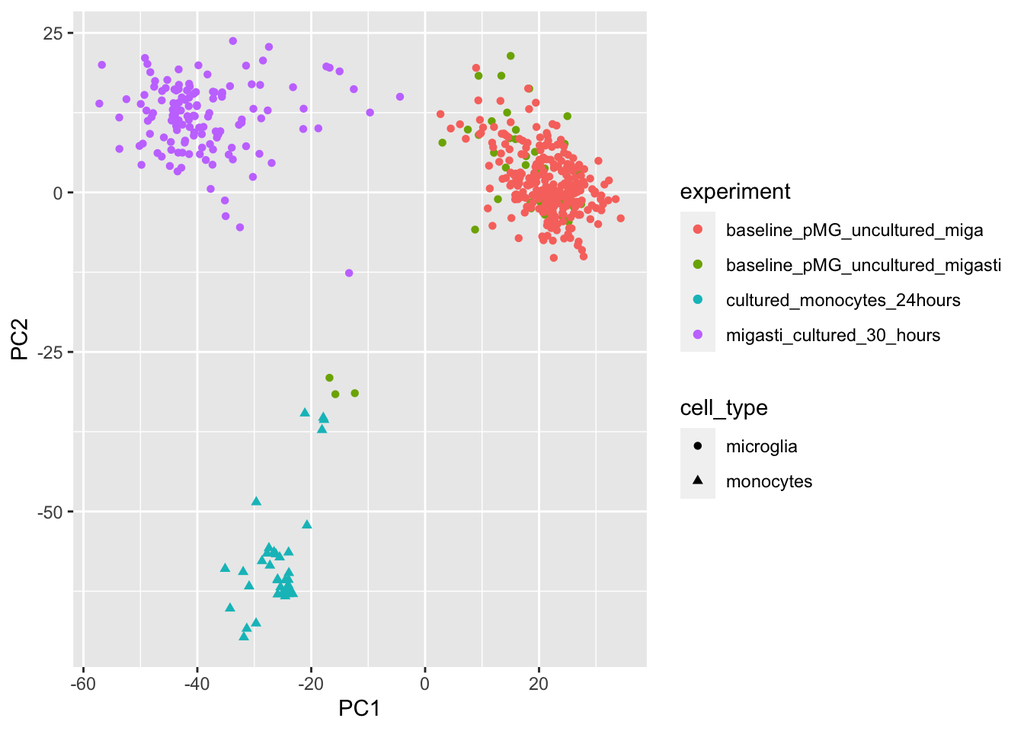

```r
PCA <- plotPCA(vsd, intgroup="experiment")
plot = as.data.frame(PCA$data)
library(plyr)
cell_type <- revalue(plot$group, c("cultured_monocytes_24hours"="monocytes", "baseline_pMG_uncultured_miga"="microglia", "baseline_pMG_uncultured_migasti"="microglia", "migasti_cultured_30_hours"="microglia"))
ggplot(data = plot, mapping = aes(x = PC1, y = PC2, colour = experiment)) +
  geom_point(aes(shape=cell_type))
```

# Include stimulation data of LPS and IFNy for monocytes and microglia

```r
metadata <- subset(metadata_filt, Stimulation == "unstim" | Stimulation == "ununstim"| Stimulation == "LPS" | Stimulation == "IFNy")
genes_counts_filt2 <- genes_counts_filt[, colnames(genes_counts_filt) %in% metadata$Sample]
head(rownames(genes_counts_filt2))
```

[1] “ENSG00000000003.14” “ENSG00000000005.6” “ENSG00000000419.12” [4] “ENSG00000000457.14” “ENSG00000000460.17” “ENSG00000000938.13”

```r
genes_counts_migasti <- genes_counts_filt2
metadata_migasti <- metadata
#check ordering
genes_counts_migasti <- genes_counts_migasti[,rownames(metadata_migasti)]
all(rownames(metadata_migasti) == colnames (genes_counts_migasti)) #TRUE
```

[1] TRUE

### number of samples MiGASti LPS 6 hours

```r
cultured <-subset(metadata_migasti, Stimulation == "LPS")
length(cultured$Sample)
```

[1] 128

```r
list(cultured$Sample)
```

[[1]] [1] “13-051-NA-LPS” “13-054-CC-LPS” “13-056-GFM-LPS” “13-074-CC-LPS”  
[5] “13-077-CC-LPS” “13-087-CC-LPS” “14-002-CC-LPS” “14-005-CC-LPS”  
[9] “14-005-GFM-LPS” “14-010-CC-LPS” “14-015-CC-LPS” “14-015-GFM-LPS” [13] “14-015-GTS-LPS” “14-029-CC-LPS” “14-029-GTS-LPS” “14-046-CC-LPS”  
[17] “14-046-GTS-LPS” “14-048-CC-LPS” “14-051-GFM-LPS” “14-053-CC-LPS”  
[21] “14-055-CC-LPS” “14-055-GFM-LPS” “14-055-GTS-LPS” “14-063-CC-LPS”  
[25] “14-069-GFM-LPS” “14-069-SVZ-LPS” “14-074-CC-LPS” “14-075-GFM-LPS” [29] “14-075-GTS-LPS” “15-018-GFM-LPS” “15-021-THA-LPS” “15-024-GFM-LPS” [33] “15-032-GTS-LPS” “15-041-GFM-LPS” “15-089-GTS-LPS” “16-003-GFM-LPS” [37] “16-003-GFS-LPS” “16-003-SVZ-LPS” “16-003-THA-LPS” “16-027-THA-LPS” [41] “16-028-GFM-LPS” “16-028-GTS-LPS” “16-028-THA-LPS” “16-049-GFM-LPS” [45] “16-049-GTS-LPS” “16-049-SVZ-LPS” “16-049-THA-LPS” “16-062-GFM-LPS” [49] “16-062-GTS-LPS” “16-062-SVZ-LPS” “16-062-THA-LPS” “16-080-SVZ-LPS” [53] “16-082-SVZ-LPS” “16-110-GFM-LPS” “16-110-THA-LPS” “16-112-GFM-LPS” [57] “16-112-GTS-LPS” “16-112-SVZ-LPS” “16-112-THA-LPS” “16-117-GFM-LPS” [61] “16-117-SVZ-LPS” “16-117-THA-LPS” “16-118-GFM-LPS” “16-118-GTS-LPS” [65] “16-118-SVZ-LPS” “16-137-SVZ-LPS” “17-003-SVZ-LPS” “17-003-THA-LPS” [69] “17-005-SVZ-LPS” “17-013-GFM-LPS” “17-013-SVZ-LPS” “17-017-GTS-LPS” [73] “17-017-SVZ-LPS” “17-017-THA-LPS” “17-029-GFM-LPS” “17-029-GTS-LPS” [77] “17-029-SVZ-LPS” “17-032-GTS-LPS” “17-032-SVZ-LPS” “17-032-THA-LPS” [81] “17-043-GFM-LPS” “17-043-SVZ-LPS” “17-043-THA-LPS” “17-074-GFM-LPS” [85] “17-074-THA-LPS” “17-078-GFM-LPS” “17-078-SVZ-LPS” “17-094-GFM-LPS” [89] “17-094-GTS-LPS” “17-094-SVZ-LPS” “17-094-THA-LPS” “17-097-GFM-LPS” [93] “17-097-GTS-LPS” “17-097-SVZ-LPS” “17-099-GFM-LPS” “17-099-GTS-LPS” [97] “17-099-SVZ-LPS” “17-099-THA-LPS” “17-102-GFM-LPS” “17-102-GTS-LPS” [101] “17-102-SVZ-LPS” “17-102-THA-LPS” “17-124-GFM-LPS” “17-124-SVZ-LPS” [105] “17-124-THA-LPS” “17-136-GFM-LPS” “17-136-SVZ-LPS” “17-148-GTS-LPS” [109] “17-148-SVZ-LPS” “18-010-GFM-LPS” “18-010-GTS-LPS” “18-010-SVZ-LPS” [113] “18-010-THA-LPS” “18-018-SVZ-LPS” “18-0198-GFM-LPS” “18-021-GFM-LPS” [117] “18-021-GTS-LPS” “18-021-THA-LPS” “18-064-GFM-LPS” “18-064-GTS-LPS” [121] “18-064-THA-LPS” “18-074-GTS-LPS” “18-074-SVZ-LPS” “18-079-SVZ-LPS” [125] “18-105-GFM-LPS” “18-105-THA-LPS” “18-112-GFM-LPS” “18-112-GTS-LPS”

### number of samples MiGASti IFNy 6 hours

```r
cultured <-subset(metadata_migasti, Stimulation == "IFNy")
length(cultured$Sample)
```

[1] 79

```r
list(cultured$Sample)
```

[[1]] [1] “13-051-NA-IFNy” “13-054-CC-IFNy” “13-056-GFM-IFNy” “13-074-CC-IFNy” [5] “13-077-CC-IFNy” “13-087-CC-IFNy” “14-005-GFM-IFNy” “14-046-CC-IFNy” [9] “14-046-GFM-IFNy” “14-048-CC-IFNy” “14-053-CC-IFNy” “14-055-CC-IFNy” [13] “14-055-GFM-IFNy” “14-063-CC-IFNy” “14-069-GFM-IFNy” “14-069-GTS-IFNy” [17] “14-075-GFM-IFNy” “14-075-GTS-IFNy” “16-003-GFM-IFNy” “16-003-GFS-IFNy” [21] “16-003-SVZ-IFNy” “16-003-THA-IFNy” “16-049-GFM-IFNy” “16-049-GTS-IFNy” [25] “16-049-SVZ-IFNy” “16-062-GFM-IFNy” “16-062-GTS-IFNy” “16-062-SVZ-IFNy” [29] “16-062-THA-IFNy” “16-080-SVZ-IFNy” “16-082-SVZ-IFNy” “16-110-GFM-IFNy” [33] “16-110-GTS-IFNy” “16-110-SVZ-IFNy” “16-112-GFM-IFNy” “16-112-GTS-IFNy” [37] “16-117-GFM-IFNy” “16-117-SVZ-IFNy” “16-117-THA-IFNy” “16-118-GFM-IFNy” [41] “16-118-GTS-IFNy” “16-118-SVZ-IFNy” “17-003-GTS-IFNy” “17-003-SVZ-IFNy” [45] “17-003-THA-IFNy” “17-005-GFM-IFNy” “17-005-GTS-IFNy” “17-005-SVZ-IFNy” [49] “17-013-SVZ-IFNy” “17-017-GFM-IFNy” “17-017-SVZ-IFNy” “17-029-SVZ-IFNy” [53] “17-032-GTS-IFNy” “17-032-SVZ-IFNy” “17-032-THA-IFNy” “17-043-GFM-IFNy” [57] “17-078-GFM-IFNy” “17-090-SVZ-IFNy” “17-094-GFM-IFNy” “17-094-SVZ-IFNy” [61] “17-094-THA-IFNy” “17-097-GFM-IFNy” “17-097-SVZ-IFNy” “17-099-GFM-IFNy” [65] “17-099-GTS-IFNy” “17-099-THA-IFNy” “17-102-SVZ-IFNy” “17-124-SVZ-IFNy” [69] “17-124-THA-IFNy” “17-136-GFM-IFNy” “18-010-GTS-IFNy” “18-010-SVZ-IFNy” [73] “18-010-THA-IFNy” “18-018-GFM-IFNy” “18-018-SVZ-IFNy” “18-039-SVZ-IFNy” [77] “18-074-SVZ-IFNy” “18-079-SVZ-IFNy” “18-112-GFM-IFNy”

# Include stimulation monocyte 24 hours LPS and IFNy

```r
load("~/Documents/Monocytes/gene_matrix.RData")
genes_counts_monocytes <- genes_counts
metadata_monocytes <- read.csv("~/Documents/Monocytes/merged_meta_lrrk2_105.csv", header=TRUE)
rownames(metadata_monocytes) = metadata_monocytes$sample_id
# check ordering of data
all(rownames(metadata_monocytes) == colnames (genes_counts_monocytes)) #TRUE
```

[1] FALSE

### number of samples monocytes LPS 24 hours

```r
cultured <-subset(metadata_monocytes, treatment == "LPS")
length(cultured$sample_id)
```

[1] 35

```r
list(cultured$sample_id)
```

[[1]] [1] “BIMD00152-01-LPS” “BIMD0043-02-LPS” “BIMD0050-02-LPS” “BIMD0052-02-LPS” [5] “BIMD0064-02-LPS” “BIMD0067-03-LPS” “BIMD0068-02-LPS” “BIMD0078-03-LPS” [9] “BIMD0105-01-LPS” “BIMD0108-01-LPS” “BIMD0109-01-LPS” “BIMD0115-01-LPS” [13] “BIMD0122-01-LPS” “BIMD0125-01-LPS” “BIMD0128-01-LPS” “BIMD0131-01-LPS” [17] “BIMD0133-01-LPS” “BIMD0137-01-LPS” “BIMD0138-01-LPS” “BIMD0139-01-LPS” [21] “BIMD0141-01-LPS” “BIMD0143-01-LPS” “BIMD0144-01-LPS” “BIMD0145-01-LPS” [25] “BIMD0149-01-LPS” “BIMD0150-01-LPS” “BIMD0159-01-LPS” “BIMD0161-01-LPS” [29] “BIMD0173-01-LPS” “BIMD0183-01-LPS” “NYUMD0065-01-LPS” “NYUMD0117-01-LPS” [33] “NYUMD0121-01-LPS” “NYUMD0123-01-LPS” “NYUMD0125-01-LPS”

### number of samples monocytes IFNy 24 hours

```r
cultured <-subset(metadata_monocytes, treatment == "IFNg")
length(cultured$sample_id)
```

[1] 35

```r
list(cultured$sample_id)
```

[[1]] [1] “BIMD00152-01-IFNg” “BIMD0043-02-IFNg” “BIMD0050-02-IFNg” [4] “BIMD0052-02-IFNg” “BIMD0064-02-IFNg” “BIMD0067-03-IFNg” [7] “BIMD0068-02-IFNg” “BIMD0078-03-IFNg” “BIMD0105-01-IFNg” [10] “BIMD0108-01-IFNg” “BIMD0109-01-IFNg” “BIMD0115-01-IFNg” [13] “BIMD0122-01-IFNg” “BIMD0125-01-IFNg” “BIMD0128-01-IFNg” [16] “BIMD0131-01-IFNg” “BIMD0133-01-IFNg” “BIMD0137-01-IFNg” [19] “BIMD0138-01-IFNg” “BIMD0139-01-IFNg” “BIMD0141-01-IFNg” [22] “BIMD0143-01-IFNg” “BIMD0144-01-IFNg” “BIMD0145-01-IFNg” [25] “BIMD0149-01-IFNg” “BIMD0150-01-IFNg” “BIMD0159-01-IFNg” [28] “BIMD0161-01-IFNg” “BIMD0173-01-IFNg” “BIMD0183-01-IFNg” [31] “NYUMD0065-01-IFNg” “NYUMD0117-01-IFNg” “NYUMD0121-01-IFNg” [34] “NYUMD0123-01-IFNg” “NYUMD0125-01-IFNg”

# Create one dataframe of all datasets including LPS and IFNy

```r
all(rownames(genes_counts_monocytes) == rownames(genes_counts_miga)) #TRUE
all(rownames(genes_counts_miga) == rownames(genes_counts_migasti)) #TRUE
all(rownames(genes_counts_monocytes) == rownames(genes_counts_migasti)) #TRUE

#create frame for metadata
metadata_miga_v <-select(metadata_miga, "donor_tissue")
metadata_migasti_v <-select(metadata_migasti, "Sample")
metadata_monocytes_v <- select(metadata_monocytes, "sample_id")

names(metadata_miga_v)[names(metadata_miga_v) == "donor_tissue"] <- "Sample"
names(metadata_monocytes_v)[names(metadata_monocytes_v) == "sample_id"] <- "Sample"

#create groups with type of experiment
experiment <- c("cultured_monocytes_24hours")
metadata_monocytes_v$experiment <- experiment
experiment <- c("baseline_pMG_MiGA")
metadata_miga_v$experiment <- experiment
experiment <- c("MiGASti")
metadata_migasti_v$experiment <- experiment

#create groups with microglia/monocytes
group <- c("monocytes")
metadata_monocytes_v$group <- group
group <- c("microglia")
metadata_miga_v$group <- group
group <- c("microglia")
metadata_migasti_v$group <- group

#rename cultured, LPS and IFNy samples in monocytes dataset
t <- grepl('B', row.names(metadata_monocytes_v))
metadata_monocytes_v[t,]$experiment <- 'cultured_monocytes_24hours'

t <- grepl('LPS', row.names(metadata_monocytes_v))
metadata_monocytes_v[t,]$experiment <- 'LPS_monocytes_24hours'

t <- grepl('IFNg', row.names(metadata_monocytes_v))
metadata_monocytes_v[t,]$experiment <- 'IFNy_monocytes_24h'

#rename cultured, LPS, IFNy and baseline in MiGASti dataset

t <- grepl('RNA', row.names(metadata_migasti_v))
metadata_migasti_v[t,]$experiment <- 'baseline_pMG_uncultured_migasti'
t <- grepl('unstim', row.names(metadata_migasti_v))
metadata_migasti_v[t,]$experiment <- 'cultured_microglia_30_hours'
t <- grepl('IFNy', row.names(metadata_migasti_v))
metadata_migasti_v[t,]$experiment <- 'IFNy_microglia_6h'
t <- grepl('LPS', row.names(metadata_migasti_v))
metadata_migasti_v[t,]$experiment <- 'LPS_microglia_6h'

identical(rownames(metadata_miga_v), colnames(genes_counts_miga))
identical(rownames(metadata_migasti_v), colnames(genes_counts_migasti))
identical(rownames(metadata_monocytes_v), colnames(genes_counts_monocytes))


genes_counts_total <- cbind(genes_counts_migasti, genes_counts_miga, genes_counts_monocytes)

metadata_total <- rbind(metadata_migasti_v, metadata_miga_v, metadata_monocytes_v)
identical(rownames(metadata_total), colnames(genes_counts_total))

genes_counts_total <- genes_counts_total[,rownames(metadata_total)]
all(rownames(metadata_total) == colnames (genes_counts_total)) #TRUE

#round counts: DESeq can only handle integers
genes_counts_total <- round(genes_counts_total, digits=0)

dds <- DESeqDataSetFromMatrix(countData = genes_counts_total,
                              colData = metadata_total,
                              design= ~ experiment)

vsd <- vst(dds, blind=FALSE)
```

### PCA of MiGASti, MiGA and cultured monocytes with LPS and IFNy included

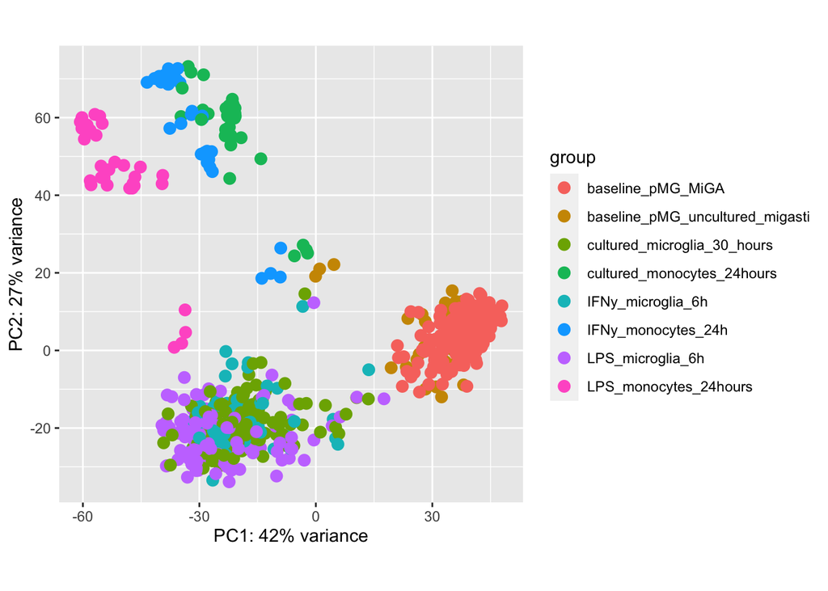

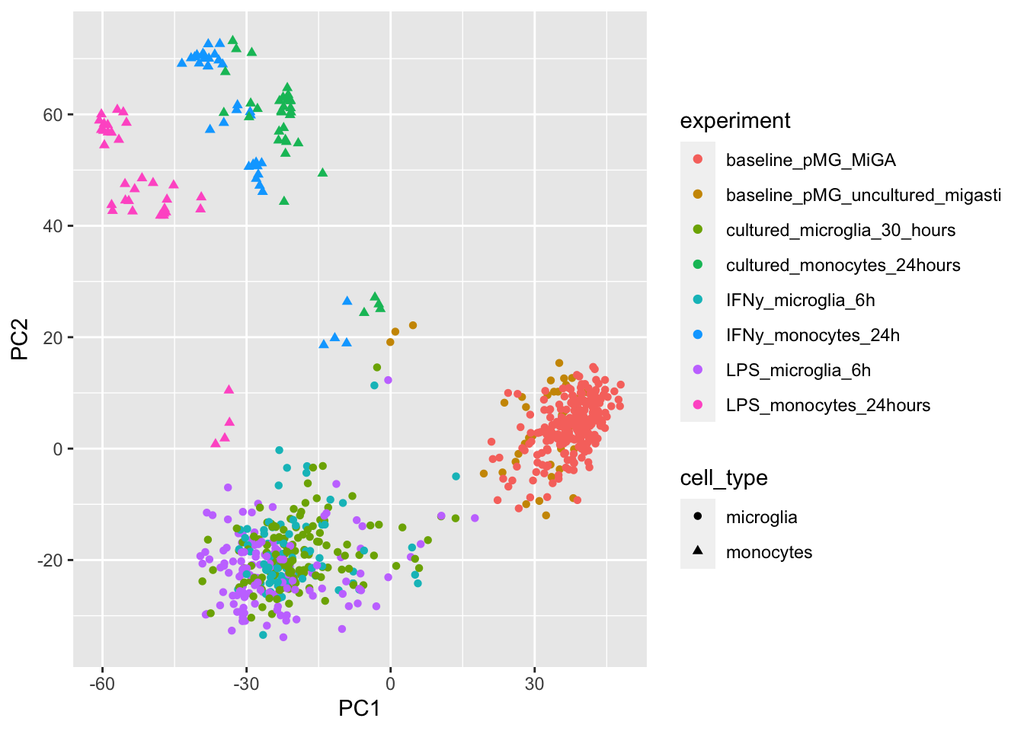

```r
plotPCA(vsd, intgroup="experiment")
PCA <- plotPCA(vsd, intgroup="experiment")
plot = as.data.frame(PCA$data)
library(plyr)
cell_type <- revalue(plot$group, c("cultured_monocytes_24hours"="monocytes", "baseline_pMG_uncultured_miga"="microglia", "baseline_pMG_uncultured_migasti"="microglia", "migasti_cultured_30_hours"="microglia", "IFNy_microglia_6h"="microglia", "LPS_microglia_6h"="microglia", "LPS_monocytes_24hours"="monocytes", "IFNy_monocytes_24h"="monocytes","cultured_microglia_30_hours"="microglia","baseline_pMG_MiGA"="microglia" ))
ggplot(data = plot, mapping = aes(x = PC1, y = PC2, colour = experiment)) +
  geom_point(aes(shape=cell_type))
```